# Tesis

CCH (2017, p. 8) estiman cada ARDL con y sin tendencia lineal y eligen con el BIC. Además, las dummies de OUT (2009T1, 2012T1 y 2015T1) se justifican con episodios de la muestra 1990-2015, por lo que se revisa si siguen siendo relevantes en 2000-2025. Como referencia exploratoria, se buscan cambios de nivel con el método de Bai y Perron (2003) en las relaciones estáticas, excluyendo la pandemia. Advertencia: las fechas surgen de los mismos datos y de regresiones en niveles, por lo que las pruebas posteriores con esas dummies deben leerse con cautela.

```r
# [Rev. 2026-09-15] Nuevo chunk: cambios estructurales de Bai y Perron (2003) en las relaciones estáticas
datos_bp <- Ldatos %>%
  filter(!Periodo %in% c("2020/02", "2020/03"))

fechas_quiebre <- function(formula, datos_bp, h = 0.15) {

  bp <- breakpoints(formula, data = datos_bp, h = h)
  n_quiebres <- which.min(summary(bp)$RSS["BIC", ]) - 1 # Número de quiebres según BIC

  if (n_quiebres == 0) return(character(0))
  datos_bp$Periodo[breakpoints(bp, breaks = n_quiebres)$breakpoints + 1] # Primer periodo de cada régimen
}

quiebres_out <- fechas_quiebre(y ~ y_usa, datos_bp)
quiebres_md <- fechas_quiebre(m ~ y + r, datos_bp)

print(quiebres_out)
```

```
## [1] "2005/03" "2009/01" "2013/01" "2018/01" "2022/01"
```

```r
print(quiebres_md)
```

```
## [1] "2004/02" "2009/01" "2012/03" "2016/01" "2020/04"
```

```r
# Escalones en las fechas encontradas (p. ej., "2005/03" -> S0503)
nombre_escalon <- function(fecha) paste0("S", gsub("/", "", substr(fecha, 3, 7)))

dummies_bp <- datos %>% dplyr::select(Periodo)
for (fecha in unique(c(quiebres_out, quiebres_md))) {
  dummies_bp[[nombre_escalon(fecha)]] <- ifelse(dummies_bp$Periodo >= fecha, 1, 0)
}
```

```r
# [Rev. 2026-09-15] Nuevo chunk: comparación de especificaciones con y sin tendencia y con distintas dummies
comparar_ardl <- function(dependiente, regresores, dummies_fijas, tendencia, datos_modelo, termino_unitario = NULL) {

  # 1. Fórmula: tendencia como regresor y dummies como términos fijos (después de "|")
  lado_derecho <- paste(c(regresores, if (tendencia) paste0("trend(", dependiente, ")")), collapse = " + ")
  formula_txt <- paste(dependiente, "~", lado_derecho)
  if (length(dummies_fijas) > 0) formula_txt <- paste(formula_txt, "|", paste(dummies_fijas, collapse = " + "))

  # 2. Selección de rezagos por BIC
  modelo <- auto_ardl(as.formula(formula_txt), data = datos_modelo, max_order = 8, selection = "BIC")
  mejor <- modelo$best_model

  # 3. Casos de Pesaran et al. (2001): sin tendencia 2 (restringida) y 3; con tendencia 4 (restringida) y 5
  casos <- if (tendencia) c(4, 5) else c(2, 3)
  f_restringido <- bounds_f_test(mejor, case = casos[1])
  f_libre <- bounds_f_test(mejor, case = casos[2])
  prueba_t <- bounds_t_test(mejor, case = casos[2])

  largo_plazo <- multipliers(mejor)
  coeficientes <- summary(mejor)$coefficients

  tibble(
    Relacion = dependiente,
    Dummies = ifelse(length(dummies_fijas) > 0, paste(dummies_fijas, collapse = ", "), "Ninguna"),
    Tendencia = ifelse(tendencia, "Sí", "No"),
    ARDL = paste0("(", paste(modelo$top_orders[1, seq_along(c(dependiente, regresores))], collapse = ","), ")"),
    BIC = modelo$top_orders$BIC[1],
    Caso_F_restringido = casos[1],
    F_restringido = f_restringido$statistic,
    Valor_p_F_restringido = f_restringido$p.value,
    F_libre = f_libre$statistic,
    Valor_p_F_libre = f_libre$p.value,
    t_libre = prueba_t$statistic,
    Valor_p_t = prueba_t$p.value,
    Largo_plazo = paste(sprintf("%s = %.3f", largo_plazo$Term[-1], largo_plazo$Estimate[-1]), collapse = "; "),
    # [Rev. 2026-09-19] Valor-p de la hipótesis de elasticidad unitaria (y = 1 en MD; y_usa = 1 en OUT)
    Valor_p_elasticidad = if (is.null(termino_unitario)) NA_real_ else {
      i <- which(largo_plazo$Term == termino_unitario)
      2 * (1 - pnorm(abs((largo_plazo$Estimate[i] - 1)/largo_plazo$`Std. Error`[i])))
    },
    Valor_p_dummies = ifelse(length(dummies_fijas) > 0,
                             paste(sprintf("%s: %.3f", dummies_fijas, coeficientes[dummies_fijas, 4]), collapse = "; "),
                             "")
  )
}

datos_especificacion <- datos_ardl %>%
  left_join(dummies_bp, by = "Periodo")

# [Rev. 2026-09-19] Se agregan las configuraciones con escalón permanente de pandemia
d_covid <- c("D202", "D203")
d_escalon <- "S2002"
d_covid_completo <- c("S2002", "D202", "D203")
d_bp_out <- nombre_escalon(quiebres_out)
d_bp_md <- nombre_escalon(quiebres_md)

especificaciones <- bind_rows(
  tibble(dependiente = "y", dummies_fijas = list(character(0), d_covid, d_escalon, d_covid_completo,
                                                 dummies_escalon, c(dummies_escalon, d_covid),
                                                 c(dummies_escalon, d_covid_completo), d_bp_out, c(d_bp_out, d_covid))),
  tibble(dependiente = "m", dummies_fijas = list(character(0), d_covid, d_escalon, d_covid_completo,
                                                 c(dummies_escalon, d_covid_completo), d_bp_md, c(d_bp_md, d_covid)))
) %>%
  crossing(tendencia = c(FALSE, TRUE))

comparacion_ardl <- especificaciones %>%
  pmap_dfr(function(dependiente, dummies_fijas, tendencia) {
    regresores <- if (dependiente == "y") "y_usa" else c("y", "r")
    termino_unitario <- if (dependiente == "y") "y_usa" else "y"
    comparar_ardl(dependiente, regresores, dummies_fijas, tendencia, datos_especificacion, termino_unitario)
  })

print(comparacion_ardl %>% dplyr::select(Relacion:Valor_p_t), n = Inf, width = Inf)
```

```
## # A tibble: 32 × 12
##    Relacion Dummies                                       Tendencia ARDL
##    <chr>    <chr>                                         <chr>     <chr>
##  1 m        Ninguna                                       No        (2,1,2)
##  2 m        Ninguna                                       Sí        (2,1,2)
##  3 m        D202, D203                                    No        (1,0,0)
##  4 m        D202, D203                                    Sí        (1,0,0)
##  5 m        S2002                                         No        (2,1,2)
##  6 m        S2002                                         Sí        (2,1,2)
##  7 m        S2002, D202, D203                             No        (1,0,0)
##  8 m        S2002, D202, D203                             Sí        (1,0,0)
##  9 m        D091, D121, D151, S2002, D202, D203           No        (1,1,0)
## 10 m        D091, D121, D151, S2002, D202, D203           Sí        (1,0,0)
## 11 m        S0402, S0901, S1203, S1601, S2004             No        (2,1,2)
## 12 m        S0402, S0901, S1203, S1601, S2004             Sí        (3,1,0)
```

[output cut: 88 more lines]

```r
print(comparacion_ardl %>% dplyr::select(Relacion, Dummies, Tendencia, Largo_plazo, Valor_p_elasticidad, Valor_p_dummies), n = Inf, width = Inf)
```

```
## # A tibble: 32 × 6
##    Relacion Dummies                                       Tendencia
##    <chr>    <chr>                                         <chr>
##  1 m        Ninguna                                       No
##  2 m        Ninguna                                       Sí
##  3 m        D202, D203                                    No
##  4 m        D202, D203                                    Sí
##  5 m        S2002                                         No
##  6 m        S2002                                         Sí
##  7 m        S2002, D202, D203                             No
##  8 m        S2002, D202, D203                             Sí
##  9 m        D091, D121, D151, S2002, D202, D203           No
## 10 m        D091, D121, D151, S2002, D202, D203           Sí
## 11 m        S0402, S0901, S1203, S1601, S2004             No
## 12 m        S0402, S0901, S1203, S1601, S2004             Sí
```

[output cut: 88 more lines]

```r
# [Rev. 2026-09-15] Lectura de resultados (con los datos actuales: Cetes 28 días y sin TED):
# - Tendencia: el BIC nunca la prefiere en OUT y en MD la diferencia es mínima (-543.5 vs. -543.7), lo que coincide con CCH (sin tendencia).
# - OUT: D091, D121 y D151 no son significativas en ninguna especificación (valores-p > 0.26), por lo que no se sostienen en 2000-2025.
#   Las dummies de la pandemia sí son significativas y el BIC elige esa especificación (-616), pero entonces ninguna prueba de límites
#   rechaza la nula (F caso 2 = 1.69, valor-p = 0.54). Sin dummies, sólo la F con constante restringida rechaza (8.36; t no rechaza).
#   Conclusión: la relación de largo plazo entre y e y_usa no se sostiene en la muestra nueva (CCH, pie de página 13, ya advertían su debilitamiento después de 2009).
# - MD: con las dummies de la pandemia, la F rechaza en los casos 2 y 3 pero la t no: resultado no concluyente.
# [Rev. 2026-09-19] Con escalón: OUT sólo con S2002 da elasticidad 0.965 (no rechaza 1) y S2002 significativa (0.001);
# con tendencia, 1.003. MD mejora mucho si además se agregan los escalones de CCH (t = -5.60), pero esos escalones no están
# en la ecuación de dinero de CCH, así que el modelo principal de MD se deja sin ellos y se reporta como robustez.
#   Con los escalones de Bai-Perron más la pandemia rechazan todas las pruebas (t = -3.90, valor-p = 0.018), pero el BIC empeora y
#   las fechas provienen de los mismos datos; se reporta sólo como evidencia exploratoria.
```

Graficar el ARDL

```r
Eq_ppp <- coint_eq(uecm_ppp, case = 2)
Eq_UIP <- coint_eq(uecm_uip, case = 2)
Eq_MD <- coint_eq(uecm_md, case = 2)
Eq_OUT <- coint_eq(uecm_out, case = 2)
```

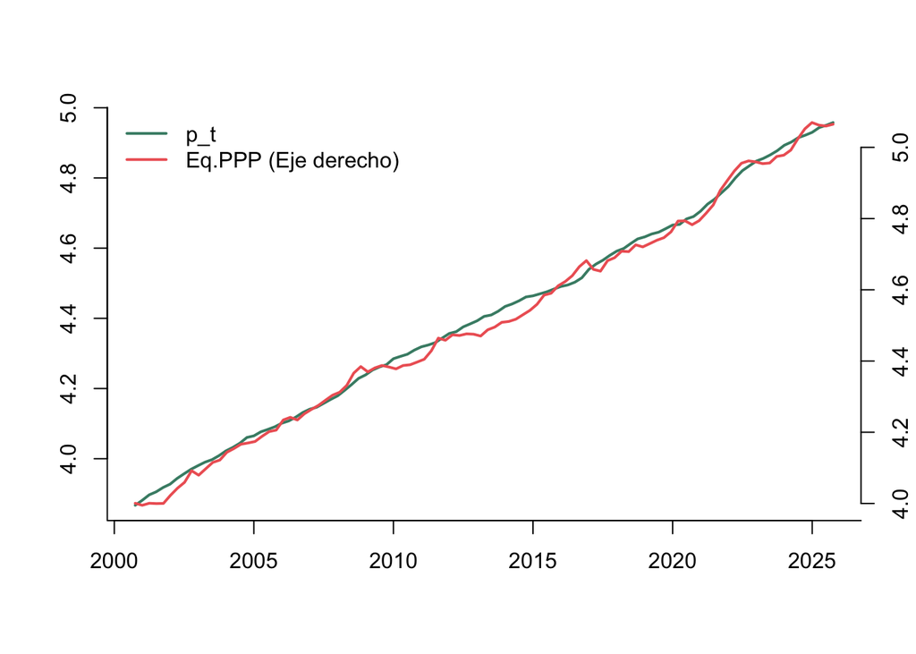

```r
serie_1_vector <- Ldatos$p
serie_2_vector <- Eq_ppp

serie_1_ts <- ts(serie_1_vector, start = c(2000, 4), frequency = 4)
serie_2_ts <- ts(serie_2_vector, start = c(2000, 4), frequency = 4)


range_1 <- range(serie_1_ts, na.rm = TRUE)
plot(serie_1_ts,
     col = "aquamarine4",
     type = "l",
     ylab = " ",
     xlab = " ",
     main = " ",
     ylim = range_1,
     lwd = 2,
     bty = "l")
par(new = TRUE)
range_2_t <- range(serie_2_ts, na.rm = TRUE)
plot(serie_2_ts,
     col = "indianred2",
     type = "l",
     axes = FALSE,
     xlab = "",
     ylab = "",
     ylim = range_2_t,
     lwd = 2)
axis(side = 4, col = "black", col.axis = "black")
mtext(" ", side = 4, line = 3, col = "indianred2")
legend("topleft",
       legend = c("p_t", "Eq.PPP (Eje derecho)"),
       col = c("aquamarine4", "indianred2"),
       lty = 1,
       lwd = 2,
       bty = "n")
```

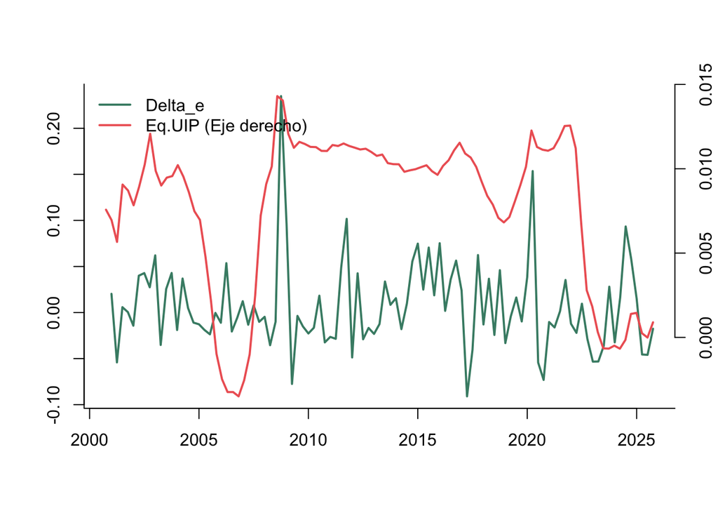

```r
serie_3_vector <- DLdatos$e
serie_4_vector <- Eq_UIP

serie_3_ts <- ts(serie_3_vector, start = c(2000, 4), frequency = 4)
serie_4_ts <- ts(serie_4_vector, start = c(2000, 4), frequency = 4)


range_3 <- range(serie_3_ts, na.rm = TRUE)
plot(serie_3_ts,
     col = "aquamarine4",
     type = "l",
     ylab = " ",
     xlab = " ",
     main = " ",
     ylim = range_3,
     lwd = 2,
     bty = "l")
par(new = TRUE)
range_4_t <- range(serie_4_ts, na.rm = TRUE)
plot(serie_4_ts,
     col = "indianred2",
     type = "l",
     axes = FALSE,
     xlab = "",
     ylab = "",
     ylim = range_4_t,
     lwd = 2)
axis(side = 4, col = "black", col.axis = "black")
mtext(" ", side = 4, line = 3, col = "indianred2")
legend("topleft",
       legend = c("Delta_e", "Eq.UIP (Eje derecho)"),
       col = c("aquamarine4", "indianred2"),
       lty = 1,
       lwd = 2,
       bty = "n")
```

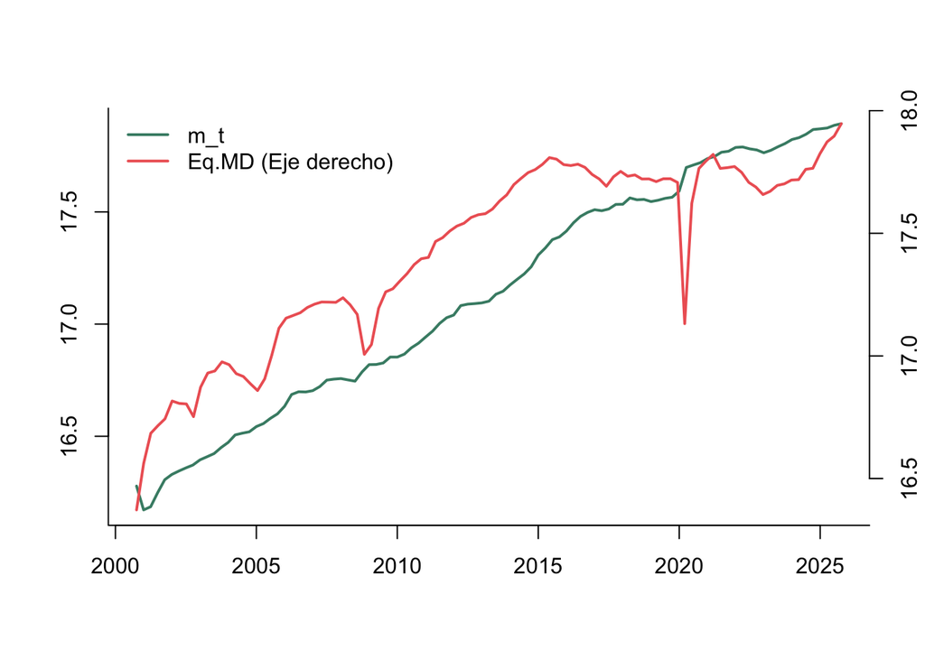

```r
serie_5_vector <- Ldatos$m
serie_6_vector <- Eq_MD

serie_5_ts <- ts(serie_5_vector, start = c(2000, 4), frequency = 4)
serie_6_ts <- ts(serie_6_vector, start = c(2000, 4), frequency = 4)


range_5 <- range(serie_5_ts, na.rm = TRUE)
plot(serie_5_ts,
     col = "aquamarine4",
     type = "l",
     ylab = " ",
     xlab = " ",
     main = " ",
     ylim = range_5,
     lwd = 2,
     bty = "l")
par(new = TRUE)
range_6 <- range(serie_6_ts, na.rm = TRUE)
plot(serie_6_ts,
     col = "indianred2",
     type = "l",
     axes = FALSE,
     xlab = "",
     ylab = "",
     ylim = range_6,
     lwd = 2)
axis(side = 4, col = "black", col.axis = "black")
mtext(" ", side = 4, line = 3, col = "indianred2")
legend("topleft",
       legend = c("m_t", "Eq.MD (Eje derecho)"),
       col = c("aquamarine4", "indianred2"),
       lty = 1,
       lwd = 2,
       bty = "n")
```

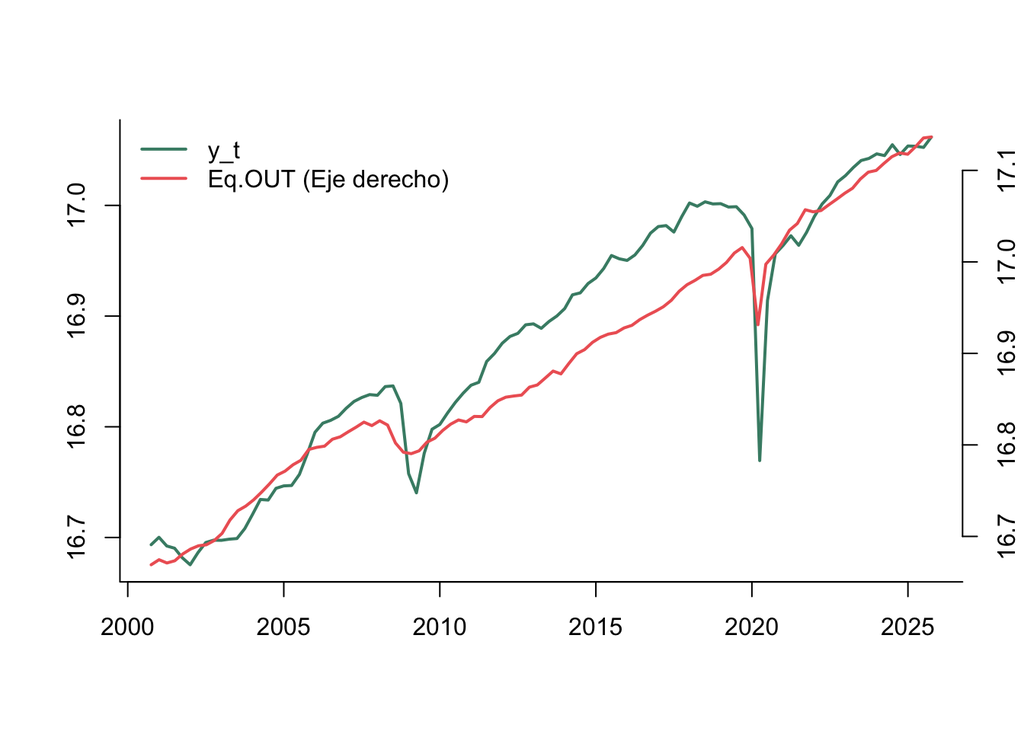

```r
serie_7_vector <- Ldatos$y
serie_8_vector <- Eq_OUT

serie_7_ts <- ts(serie_7_vector, start = c(2000, 4), frequency = 4)
serie_8_ts <- ts(serie_8_vector, start = c(2000, 4), frequency = 4)


range_7 <- range(serie_7_ts, na.rm = TRUE)
plot(serie_7_ts,
     col = "aquamarine4",
     type = "l",
     ylab = " ",
     xlab = " ",
     main = " ",
     ylim = range_7,
     lwd = 2,
     bty = "l")
par(new = TRUE)
range_8 <- range(serie_8_ts, na.rm = TRUE)
plot(serie_8_ts,
     col = "indianred2",
     type = "l",
     axes = FALSE,
     xlab = "",
     ylab = "",
     ylim = range_8,
     lwd = 2)
axis(side = 4, col = "black", col.axis = "black")
mtext(" ", side = 4, line = 3, col = "indianred2")
legend("topleft",
       legend = c("y_t", "Eq.OUT (Eje derecho)"),
       col = c("aquamarine4", "indianred2"),
       lty = 1,
       lwd = 2,
       bty = "n")
```

#Bloque 4: Rango de cointegración

Primero se selecciona el número de rezagos óptimos del VAR subyacente

```r
# [Rev. 2026-09-15] Exógenas en primeras diferencias con un rezago y dummies, como en CCH (2017, p. 13)
# Original: datos_var_sub<- Ldatos %>%
# Original:   mutate(
# Original:     dif_e = e - lag(e),
# Original:     ti = p_usa + e) %>%
# Original:   slice(-1)
datos_var_sub<- Ldatos %>%
  left_join(dummies, by = "Periodo") %>%
  mutate(
    dif_e = e - lag(e),
    ti = p_usa + e,
    d_wti_l1 = lag(wti - lag(wti)),
    d_pp_usa_l1 = lag(pp_usa - lag(pp_usa)),
    d_ted_l1 = lag(ted - lag(ted))) %>%
  slice(-(1:2))



# 1. Definir nombres de las variables endógenas y exógenas
vars_endogenas <- c("y", "p", "dif_e", "r", "m", "y_usa", "r_usa", "ti")
# [Rev. 2026-09-15] Exógenas en diferencias rezagadas y dummies
# Original: vars_exogenas  <- c("pp_usa", "wti")
# [Rev. 2026-09-18] Se agrega el diferencial de financiamiento, como en CCH (2017, p. 5)
vars_exogenas  <- c("d_pp_usa_l1", "d_wti_l1", "d_ted_l1", dummies_escalon, dummies_covid)


# 3. Convertir a matrices/data.frames numéricos
y_mat <- as.matrix(datos_var_sub[, vars_endogenas])
x_mat <- as.matrix(datos_var_sub[, vars_exogenas])

# 4. Ejecutar VARselect con variables exógenas
seleccion_rezagos <- VARselect(
  y = y_mat,
  # [Rev. 2026-09-15] CCH (2017, Tabla 4) evalúan de 1 a 4 rezagos
  # Original: lag.max = 6,          # Máximo de rezagos a evaluar
  lag.max = 4,          # Máximo de rezagos a evaluar
  type = "const",       # "const", "trend", "both" o "none"
  exogen = x_mat
)

# Rezagos óptimos sugeridos por AIC, HQ, SC/BIC y FPE
print(seleccion_rezagos$selection)
```

```
## AIC(n)  HQ(n)  SC(n) FPE(n)
##      2      2      1      2
```

```r
# Valores de los criterios para cada rezago (p = 1 hasta lag.max)
print(round(seleccion_rezagos$criteria, 4))
```

```
##               1        2        3        4
## AIC(n) -85.6433 -86.7331 -86.5773 -86.3745
## HQ(n)  -84.0791 -84.4736 -83.6227 -82.7247
## SC(n)  -81.7721 -81.1414 -79.2652 -77.3419
## FPE(n)   0.0000   0.0000   0.0000   0.0000
```